# Bike Sharing Dataset

Group 2 (LV-Nr: 0987): Nurzhanat Zhussup, Karla Gale, Mariia Slobodianyk, Meltem Ekin, Muslim Issayev

# Introduction

Bike sharing systems are new generation of traditional bike rentals where whole process from membership, rental and return back has become automatic. Through these systems, user is able to easily rent a bike from a particular position and return back at another position. Currently, there are about over 500 bike-sharing programs around the world which is composed of over 500 thousands bicycles. Today, there exists great interest in these systems due to their important role in traffic, environmental and health issues.

# Motivation for research

Leveraging User Behavior for Bike-Sharing Business Success Bike-sharing systems have transformed urban transportation. Understanding user behavior is pivotal for enhancing operational efficiency and crafting effective marketing strategies. This research seeks to unveil user patterns impacted by seasons, weather, weekdays, and holidays. The insights generated will empower bike-sharing businesses to optimize resources and attract and retain users, fostering system growth and economic sustainability.

# Research questions

- How different are bike rental behaviors between casual and registered users?
- What are the bike rental patterns across seasons and months
- What is the impact of different weather conditions on bike rental
- Is there any significant differences in bike rental on holidays and workdays?
- Which variables are most important in predicting total number bike rentals?

# Data description

```
- instant: record index
- dteday : date
- season : season (1:winter, 2:spring, 3:summer, 4:fall)
- yr : year (0: 2011, 1:2012)
- mnth : month ( 1 to 12)
- hr : hour (0 to 23)
- holiday : weather day is holiday or not (extracted from http://dchr.dc.gov/page/holiday-schedule)
- weekday : day of the week
- workingday : if day is neither weekend nor holiday is 1, otherwise is 0.
- weathersit :
    - 1: Clear, Few clouds, Partly cloudy, Partly cloudy
    - 2: Mist + Cloudy, Mist + Broken clouds, Mist + Few clouds, Mist
    - 3: Light Snow, Light Rain + Thunderstorm + Scattered clouds, Light Rain + Scattered clouds
    - 4: Heavy Rain + Ice Pallets + Thunderstorm + Mist, Snow + Fog
- temp : Normalized temperature in Celsius. The values are derived via (t-t_min)/(t_max-t_min), t_min=-8, t_max=+39 (only in hourly scale)
- atemp: Normalized feeling temperature in Celsius. The values are derived via (t-t_min)/(t_max-t_min), t_min=-16, t_max=+50 (only in hourly scale)
- hum: Normalized humidity. The values are divided to 100 (max)
- windspeed: Normalized wind speed. The values are divided to 67 (max)
- casual: count of casual users
- registered: count of registered users
- cnt: count of total rental bikes including both casual and registered
```

# Data

## Data import

```r
bike <- read.csv(file = "bike+sharing+dataset/hour.csv", header = TRUE)
```

## Data structure

```r
str(bike)
```

```
'data.frame':   17379 obs. of  17 variables:
 $ instant   : int  1 2 3 4 5 6 7 8 9 10 ...
 $ dteday    : chr  "2011-01-01" "2011-01-01" "2011-01-01" "2011-01-01" ...
 $ season    : int  1 1 1 1 1 1 1 1 1 1 ...
 $ yr        : int  0 0 0 0 0 0 0 0 0 0 ...
 $ mnth      : int  1 1 1 1 1 1 1 1 1 1 ...
 $ hr        : int  0 1 2 3 4 5 6 7 8 9 ...
 $ holiday   : int  0 0 0 0 0 0 0 0 0 0 ...
 $ weekday   : int  6 6 6 6 6 6 6 6 6 6 ...
 $ workingday: int  0 0 0 0 0 0 0 0 0 0 ...
 $ weathersit: int  1 1 1 1 1 2 1 1 1 1 ...
 $ temp      : num  0.24 0.22 0.22 0.24 0.24 0.24 0.22 0.2 0.24 0.32 ...
 $ atemp     : num  0.288 0.273 0.273 0.288 0.288 ...
 $ hum       : num  0.81 0.8 0.8 0.75 0.75 0.75 0.8 0.86 0.75 0.76 ...
 $ windspeed : num  0 0 0 0 0 0.0896 0 0 0 0 ...
 $ casual    : int  3 8 5 3 0 0 2 1 1 8 ...
 $ registered: int  13 32 27 10 1 1 0 2 7 6 ...
 $ cnt       : int  16 40 32 13 1 1 2 3 8 14 ...
```

## Duplicated values

```r
bike[duplicated(bike),]
```

| instant | dteday | season | yr | mnth | hr | holiday | weekday | workingday | weathersit | temp | atemp | hum | windspeed | casual | registered | cnt |
| --- | --- | --- | --- | --- | --- | --- | --- | --- | --- | --- | --- | --- | --- | --- | --- | --- |

**NO DUPLICATED DATA**

## Data formatting

```r
bike$dteday <- NULL
bike$instant <- NULL
```

Delete the dteday variable because the information as year, month, weekday, holiday, workingday, season and hour are already extracted.

Delete the instant variable because it’s just the row count

## Data summary

```r
summary(bike)
```

```
     season            yr              mnth              hr           holiday           weekday
 Min.   :1.000   Min.   :0.0000   Min.   : 1.000   Min.   : 0.00   Min.   :0.00000   Min.   :0.000
 1st Qu.:2.000   1st Qu.:0.0000   1st Qu.: 4.000   1st Qu.: 6.00   1st Qu.:0.00000   1st Qu.:1.000
 Median :3.000   Median :1.0000   Median : 7.000   Median :12.00   Median :0.00000   Median :3.000
 Mean   :2.502   Mean   :0.5026   Mean   : 6.538   Mean   :11.55   Mean   :0.02877   Mean   :3.004
 3rd Qu.:3.000   3rd Qu.:1.0000   3rd Qu.:10.000   3rd Qu.:18.00   3rd Qu.:0.00000   3rd Qu.:5.000
 Max.   :4.000   Max.   :1.0000   Max.   :12.000   Max.   :23.00   Max.   :1.00000   Max.   :6.000
   workingday       weathersit         temp           atemp             hum           windspeed
 Min.   :0.0000   Min.   :1.000   Min.   :0.020   Min.   :0.0000   Min.   :0.0000   Min.   :0.0000
 1st Qu.:0.0000   1st Qu.:1.000   1st Qu.:0.340   1st Qu.:0.3333   1st Qu.:0.4800   1st Qu.:0.1045
 Median :1.0000   Median :1.000   Median :0.500   Median :0.4848   Median :0.6300   Median :0.1940
 Mean   :0.6827   Mean   :1.425   Mean   :0.497   Mean   :0.4758   Mean   :0.6272   Mean   :0.1901
 3rd Qu.:1.0000   3rd Qu.:2.000   3rd Qu.:0.660   3rd Qu.:0.6212   3rd Qu.:0.7800   3rd Qu.:0.2537
 Max.   :1.0000   Max.   :4.000   Max.   :1.000   Max.   :1.0000   Max.   :1.0000   Max.   :0.8507
     casual         registered         cnt
 Min.   :  0.00   Min.   :  0.0   Min.   :  1.0
 1st Qu.:  4.00   1st Qu.: 34.0   1st Qu.: 40.0
 Median : 17.00   Median :115.0   Median :142.0
 Mean   : 35.68   Mean   :153.8   Mean   :189.5
 3rd Qu.: 48.00   3rd Qu.:220.0   3rd Qu.:281.0
 Max.   :367.00   Max.   :886.0   Max.   :977.0
```

All variables are already numeric.

## Missing values

```r
colSums(is.na(bike))
```

```
    season         yr       mnth         hr    holiday    weekday workingday weathersit       temp
         0          0          0          0          0          0          0          0          0
     atemp        hum  windspeed     casual registered        cnt
         0          0          0          0          0          0
```

**NO MISSING VALUES**

# Exploratory data analysis

```r
library(corrplot)
```

## Correlation

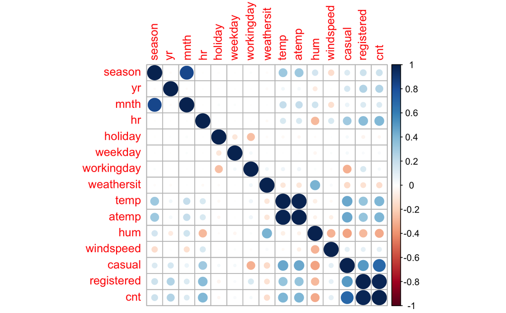

```r
corrplot(cor(bike[,sapply(bike, is.numeric)]))
```

There seem to be:

- Very strong correlation between cnt and registered, but it’s only correlated because cnt = casual + registered. Next visual showcases this situation.
- Very strong correlation between atemp and temp, but it’s explained by the fact that atemp is just a feeling temperature of the nominal temperature
- Strong correlation between season and month, but it’s explained logically that the seasons include months. So these correlations aren’t significant for our predictions.

In fact, cnt is good correlated with the following variables:

- hr (positive)
- temp & atemp (positive)
- hum (negative)

**Next visuals will show in details the relationship between cnt and each independent variable**

## Casual vs. Registered

**Differences in rental behaviors between casual and registered users**

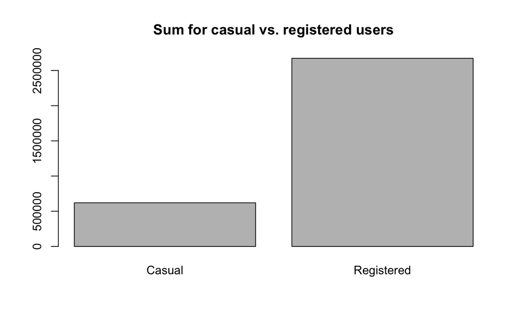

```r
barplot(c(sum(bike$casual), sum(bike$registered)), names.arg = c("Casual", "Registered"), main = "Sum for casual vs. registered users")
```

This basically explains why cnt is highly correlated with registered. There are a lot more registered customers than casual. cnt is just the sum of casual and registered.

### by season

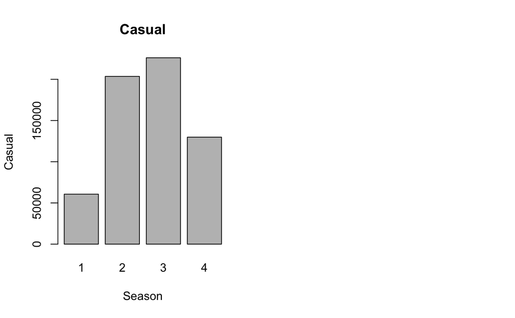

```r
par(mfrow = c(1,2))

barplot(tapply(bike$casual, bike$season, sum), beside = TRUE,
        main = "Casual",
        xlab = "Season",
        ylab = "Casual")
barplot(tapply(bike$registered, bike$season, sum), beside = TRUE,
        main = "Registered",
        xlab = "Season",
        ylab = "Count of Rentals")
```

Registered customers have more bike rentals in winter and fall than casual customers.

### by hour

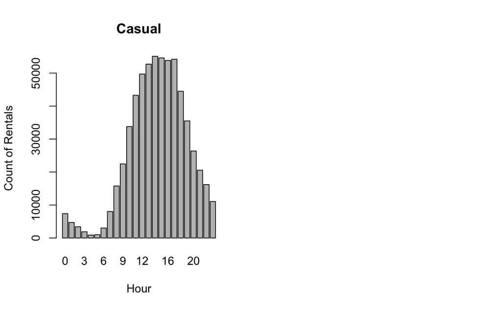

```r
par(mfrow = c(1,2))

barplot(tapply(bike$casual, bike$hr, sum), beside = TRUE,
        main = "Casual",
        xlab = "Hour",
        ylab = "Count of Rentals")
barplot(tapply(bike$registered, bike$hr, sum), beside = TRUE,
        main = "Registered",
        xlab = "Hour",
        ylab = "Count of Rentals")
```

Casual customers mostly rent bikes in the mid-day time. For registered customers, the peak rental time is in the morning and evening, or, in other words, at the start and end of work.

### by workingday

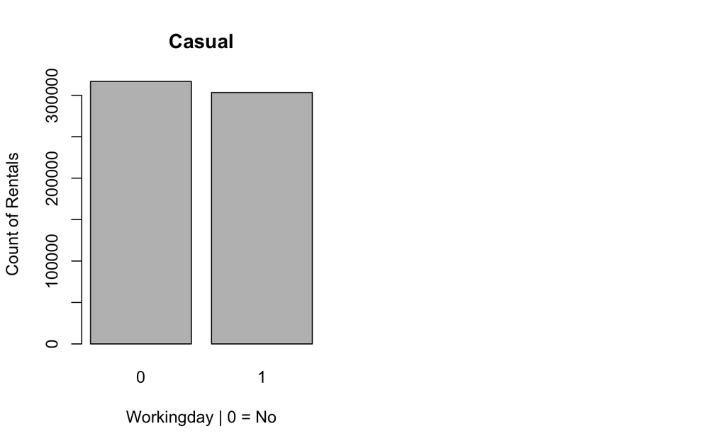

```r
par(mfrow = c(1,2))

barplot(tapply(bike$casual, bike$workingday, sum), beside = TRUE,
        main = "Casual",
        xlab = "Workingday | 0 = No",
        ylab = "Count of Rentals")
barplot(tapply(bike$registered, bike$workingday, sum), beside = TRUE,
        main = "Registered",
        xlab = "1 = Yes | Workingday ",
        ylab = "Count of Rentals")
```

After this visual we can assume that registered customers are local working people who use bike rentals to commute to work. Casual customers can be tourists , as their rental behavior is indifferent between working days and holidays. But these are just assumptions.

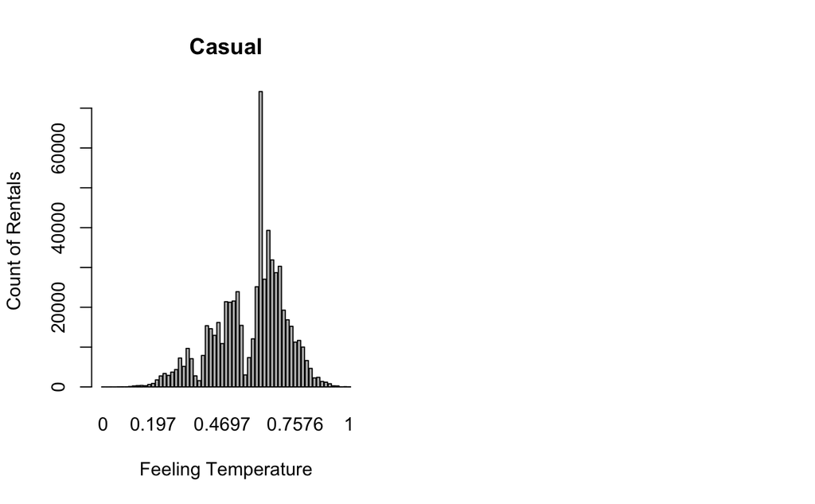

```r
par(mfrow = c(1,2))

barplot(tapply(bike$casual, bike$atemp, sum), beside = TRUE,
        main = "Casual",
        xlab = "Feeling Temperature",
        ylab = "Count of Rentals")
barplot(tapply(bike$registered, bike$atemp, sum), beside = TRUE,
        main = "Registered",
        xlab = "Feeling Temperature",
        ylab = "Count of Rentals")
```

Registered customers rent bikes on colder days also. Casulas not so often.

## Total count (cnt)

cnt = registered + casual

**Overall rental behavior across different weather situations and daytimes**

### Outliers cnt

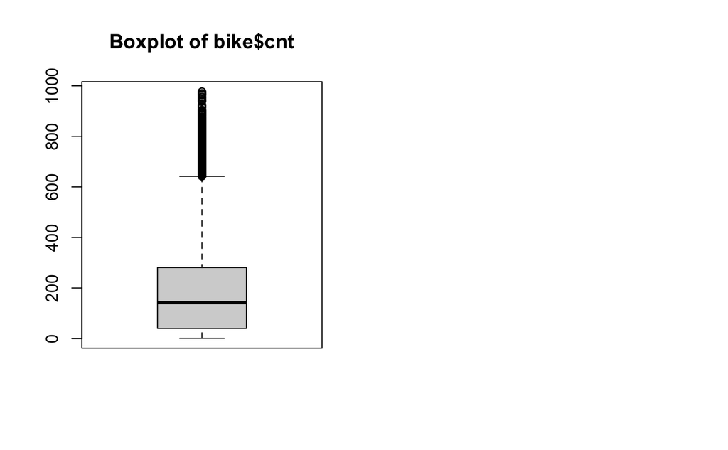

```r
par(mfrow=c(1,2))
boxplot(bike$cnt, main='Boxplot of bike$cnt')
hist(bike$cnt,)
```

**TOTAL COUNT OF RENTALS HAS STRONG RIGHT-SKEWED DISTRIBUTION, THEREFORE IT HAS SOME OUTLIERS BEGINNING FROM APPROX. 650 RENTALS. THIS MAY BE EXPLAINED BY NON LINEAR DISTRIBUTION OF THE INDEPENDENT VARIABLES. EG. A LOT MORE TOURISTS IN SUMMER THEREFORE, BIG INCREASE IN BIKE RENTALS IN SUMMER FOR SHORT PERIOD**

### by season

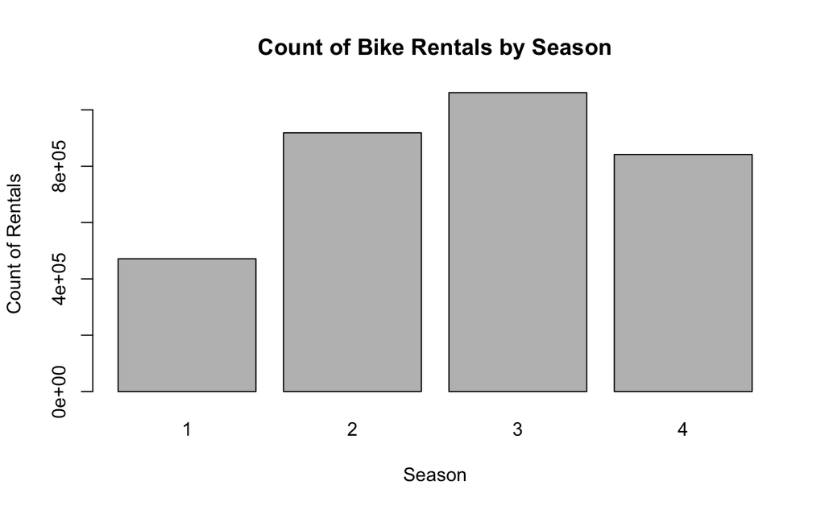

```r
barplot(tapply(bike$cnt, bike$season, sum), beside = TRUE,
        main = "Count of Bike Rentals by Season",
        xlab = "Season",
        ylab = "Count of Rentals")
```

The are much more bike rentals in summer than in winter. And it’s actually make sense, because most people would prefer to ride in warm summer times rather than in cold winter times.

### by year

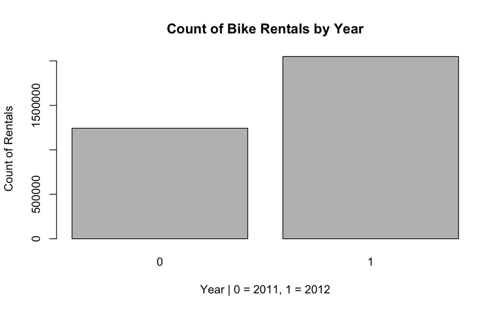

```r
barplot(tapply(bike$cnt, bike$yr, sum), beside = TRUE,
        main = "Count of Bike Rentals by Year",
        xlab = "Year | 0 = 2011, 1 = 2012",
        ylab = "Count of Rentals")
```

This visual can show that our bike rental company has gained popularity between years 2011 and 2012. There are more bike rentals in 2012.

### by month

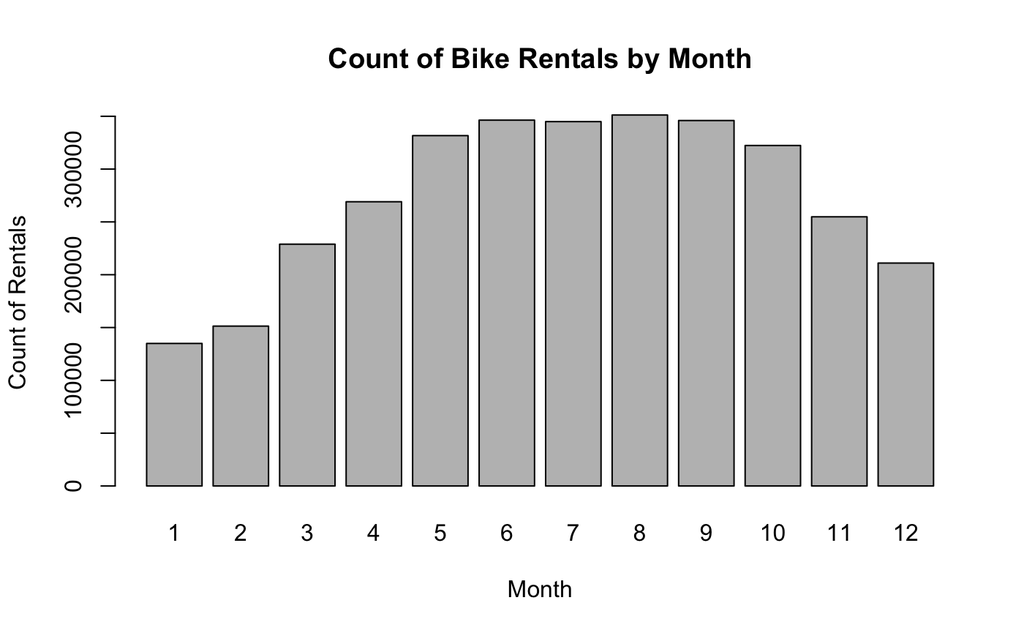

```r
barplot(tapply(bike$cnt, bike$mnth, sum), beside = TRUE,
        main = "Count of Bike Rentals by Month",
        xlab = "Month",
        ylab = "Count of Rentals")
```

This visual explains the correlation between season and month. It also correlates with season barplot. There are much more bike rentals in summer times. (from 5th to 9-10th month)

### by hour

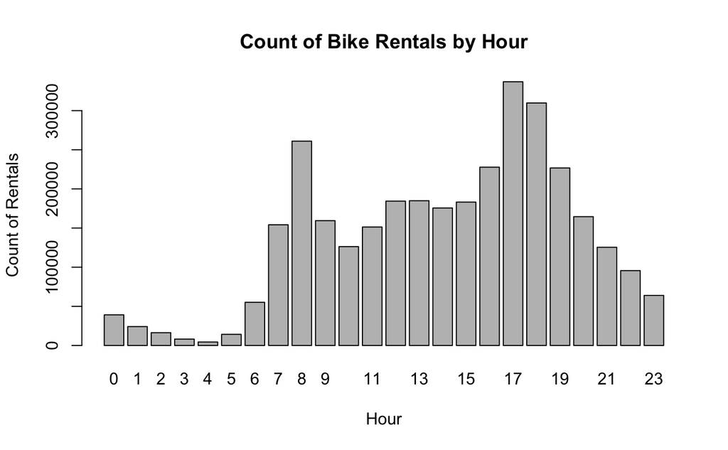

```r
barplot(tapply(bike$cnt, bike$hr, sum), beside = TRUE,
        main = "Count of Bike Rentals by Hour",
        xlab = "Hour",
        ylab = "Count of Rentals")
```

The bike rental peaks are mainly during the morning (8 am.) and evening (5 pm. - 7pm.; 17:00-19:00) hours.

### by holiday and workingday

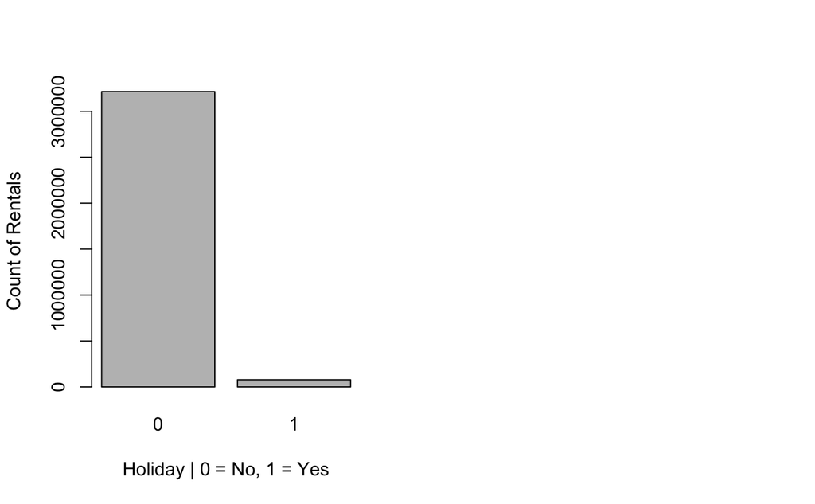

```r
par(mfrow = c(1,2))
barplot(tapply(bike$cnt, bike$holiday, sum), beside = TRUE,
        xlab = "Holiday | 0 = No, 1 = Yes",
        ylab = "Count of Rentals")
barplot(tapply(bike$cnt, bike$workingday, sum), beside = TRUE,
        xlab = "Workingday | 0 = No, 1 = Yes",
        ylab = "Count of Rentals")
```

There are much less holidays than casual days. Therefore, not evenly distributed.

There are more bike rentals on working days than on holidays or weekends.

Combined with the hours and visual representation of the working day, it can be assumed that the majority of bike rental revenue is generated by working people who rent our bikes to commute to their place of work and return home during the evening hours